# kiki/bouba Bayesian model

Bodo Winter

8/8/2019

## Introduction

This script takes the models that are produced by “bayes_models.R” and reports summary results:

Load packages:

```r
library(tidyverse)
library(brms)
library(gridExtra)
```

Load ggplot2 theme:

```r
source('theme_timo.R')
```

Get data to plot descriptive averages to the model:

```r
kiki <- read_csv('../data/web_experiment_cleaned.csv')
```

Load ggplot2 theme:

```r
source('theme_timo.R')
```

Load the model:

```r
load('../models/kiki_mdl.RData')
load('../models/kiki_script_mdl.RData')
load('../models/daakie_mdl.RData')
load('../models/kiki_AnyRoman_mdl.RData')
load('../models/kiki_scriptL2_mdl.RData')
```

Load language data for plotting:

```r
lang_info <- read_csv('../data/language_info.csv')
```

## Posterior predictive checks:

Posterior predictive checks:

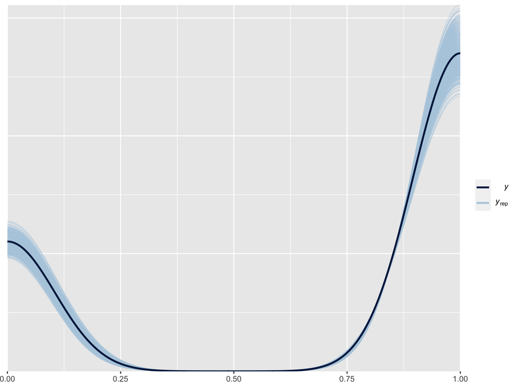

```r
pp_check(kiki_mdl, nsample = 1000)
```

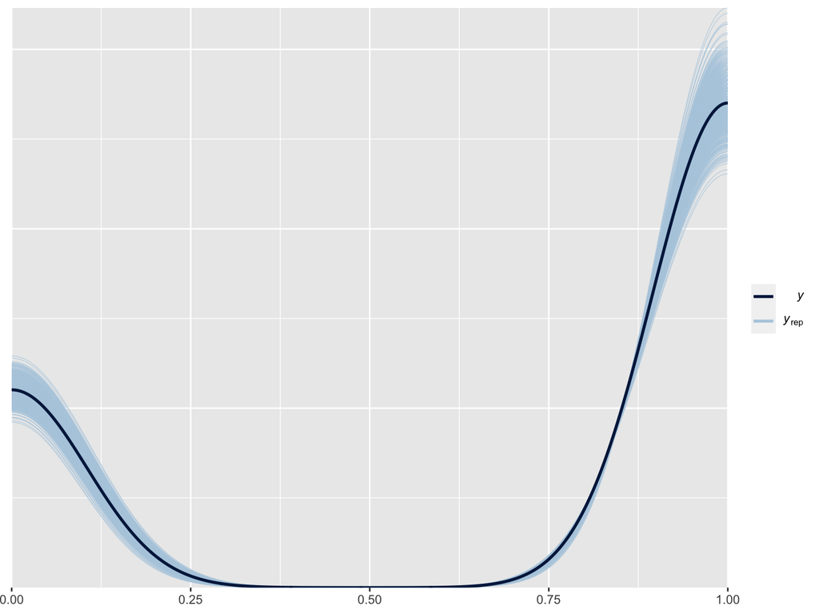

```r
pp_check(kiki_script_mdl, nsample = 1000)
```

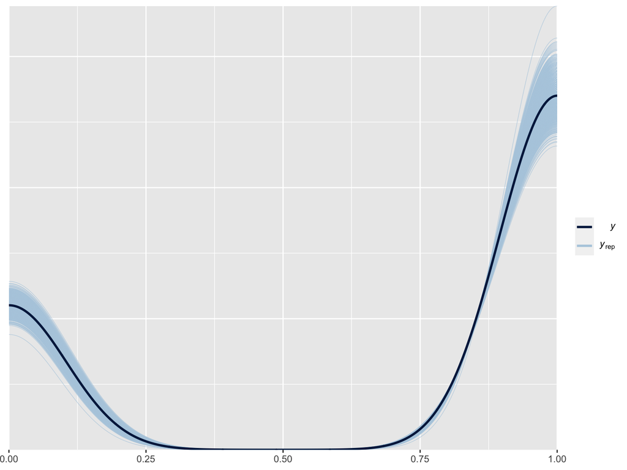

```r
pp_check(kiki_AnyRoman_mdl, nsample = 1000)
```

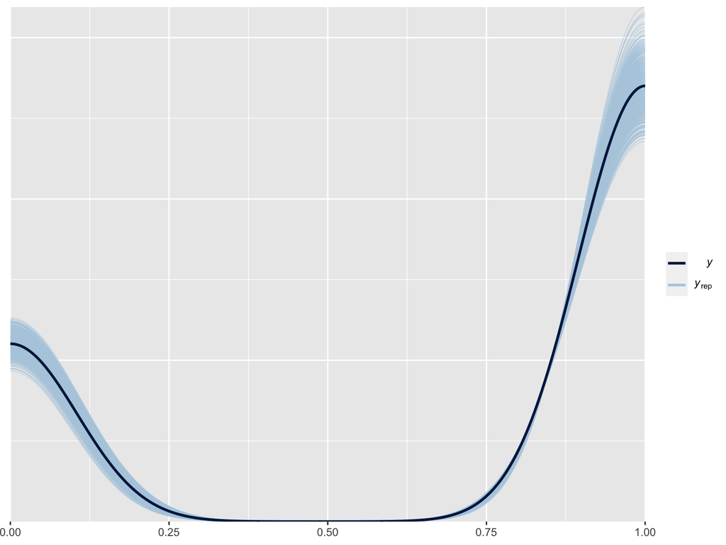

```r
pp_check(kiki_scriptL2_mdl, nsample = 1000)
```

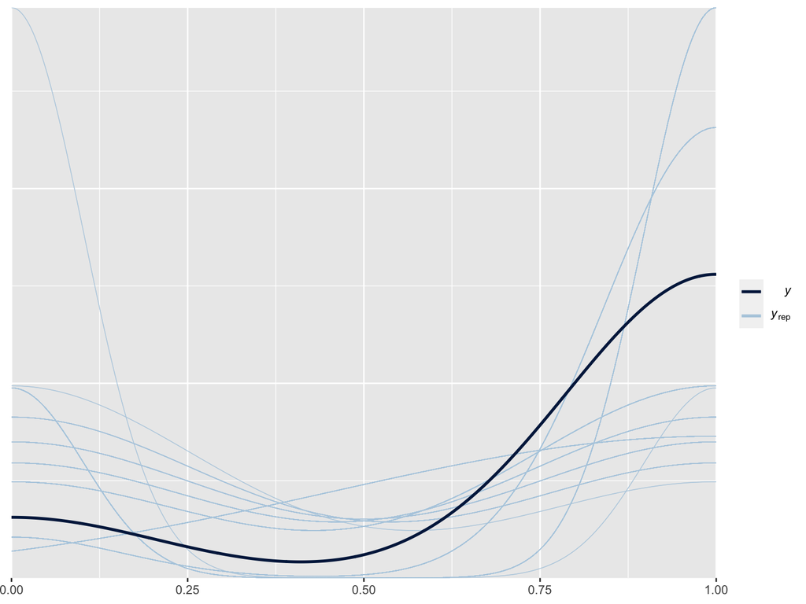

```r
pp_check(daakie_mdl, nsample = 1000)
```

## Summarize models:

First, overall summary:

```r
summary(kiki_mdl)
```

```
##  Family: bernoulli
##   Links: mu = logit
## Formula: Match ~ 1 + (1 | Language) + (1 | Family)
##    Data: kiki (Number of observations: 897)
## Samples: 4 chains, each with iter = 6000; warmup = 4000; thin = 1;
##          total post-warmup samples = 8000
##
## Group-Level Effects:
## ~Family (Number of levels: 9)
##               Estimate Est.Error l-95% CI u-95% CI Rhat Bulk_ESS Tail_ESS
## sd(Intercept)     0.47      0.39     0.02     1.42 1.00     1472     2550
##
## ~Language (Number of levels: 24)
##               Estimate Est.Error l-95% CI u-95% CI Rhat Bulk_ESS Tail_ESS
## sd(Intercept)     0.83      0.19     0.51     1.27 1.00     2335     4473
##
## Population-Level Effects:
##           Estimate Est.Error l-95% CI u-95% CI Rhat Bulk_ESS Tail_ESS
## Intercept     0.92      0.31     0.29     1.53 1.00     3034     3543
##
## Samples were drawn using sampling(NUTS). For each parameter, Bulk_ESS
## and Tail_ESS are effective sample size measures, and Rhat is the potential
## scale reduction factor on split chains (at convergence, Rhat = 1).
```

Extract the posteriors:

```r
web_posts <- posterior_samples(kiki_mdl)
```

Get the 95% credible interval in terms of predicted probabilities:

```r
plogis(mean(web_posts$b_Intercept))
```

```
## [1] 0.7142719
```

```r
plogis(quantile(web_posts$b_Intercept, 0.025))
```

```
##      2.5%
## 0.5708963
```

```r
plogis(quantile(web_posts$b_Intercept, 0.975))
```

```
##     97.5%
## 0.8225961
```

```r
sum(web_posts$b_Intercept < 0) / nrow(web_posts)
```

```
## [1] 0.005625
```

## Check orthography-related effects in web-based experiments:

Check script effect in web experiment:

```r
summary(kiki_script_mdl)
```

```
##  Family: bernoulli
##   Links: mu = logit
## Formula: Match ~ Script + (1 | Language) + (1 | Family)
##    Data: kiki (Number of observations: 897)
## Samples: 4 chains, each with iter = 6000; warmup = 4000; thin = 1;
##          total post-warmup samples = 8000
##
## Group-Level Effects:
## ~Family (Number of levels: 9)
##               Estimate Est.Error l-95% CI u-95% CI Rhat Bulk_ESS Tail_ESS
## sd(Intercept)     0.57      0.45     0.03     1.66 1.00     1441     2958
##
## ~Language (Number of levels: 24)
##               Estimate Est.Error l-95% CI u-95% CI Rhat Bulk_ESS Tail_ESS
## sd(Intercept)     0.78      0.19     0.46     1.20 1.00     2539     3803
##
## Population-Level Effects:
##             Estimate Est.Error l-95% CI u-95% CI Rhat Bulk_ESS Tail_ESS
## Intercept       0.58      0.41    -0.24     1.35 1.00     4201     4237
## Scriptroman     0.64      0.43    -0.20     1.52 1.00     2699     4156
##
## Samples were drawn using sampling(NUTS). For each parameter, Bulk_ESS
## and Tail_ESS are effective sample size measures, and Rhat is the potential
## scale reduction factor on split chains (at convergence, Rhat = 1).
```

Get the posterior predictions:

```r
script_posts <- posterior_samples(kiki_script_mdl)
```

Check whether the coefficients are reliably different from 0:

```r
sum(script_posts$b_Scriptroman < 0) / nrow(script_posts)
```

```
## [1] 0.065
```

What is the predicted increase in probability for roman script?

```r
# Non-roman script:

plogis(fixef(kiki_script_mdl)[1, 1])
```

```
## [1] 0.6407871
```

```r
# Roman script:

plogis(fixef(kiki_script_mdl)[1, 1] + fixef(kiki_script_mdl)[2, 1])
```

```
## [1] 0.7715318
```

```r
# Odds:

exp(fixef(kiki_script_mdl)[2, 1])
```

```
## [1] 1.893068
```

## Check the L2 related effects:

Check script effect in web experiment:

```r
summary(kiki_AnyRoman_mdl)
```

```
##  Family: bernoulli
##   Links: mu = logit
## Formula: Match ~ 1 + KnowsAnyRoman + (1 | Language) + (1 | Family)
##    Data: kiki (Number of observations: 897)
## Samples: 4 chains, each with iter = 6000; warmup = 4000; thin = 1;
##          total post-warmup samples = 8000
##
## Group-Level Effects:
## ~Family (Number of levels: 9)
##               Estimate Est.Error l-95% CI u-95% CI Rhat Bulk_ESS Tail_ESS
## sd(Intercept)     0.50      0.41     0.02     1.48 1.00     1359     2983
##
## ~Language (Number of levels: 24)
##               Estimate Est.Error l-95% CI u-95% CI Rhat Bulk_ESS Tail_ESS
## sd(Intercept)     0.83      0.19     0.51     1.25 1.00     2612     4581
##
## Population-Level Effects:
##                  Estimate Est.Error l-95% CI u-95% CI Rhat Bulk_ESS
## Intercept            0.89      0.48    -0.05     1.83 1.00     4497
## KnowsAnyRomanyes     0.04      0.38    -0.70     0.79 1.00     9153
##                  Tail_ESS
## Intercept            5335
## KnowsAnyRomanyes     5982
##
## Samples were drawn using sampling(NUTS). For each parameter, Bulk_ESS
## and Tail_ESS are effective sample size measures, and Rhat is the potential
## scale reduction factor on split chains (at convergence, Rhat = 1).
```

Get the posterior predictions:

```r
L2_posts <- posterior_samples(kiki_AnyRoman_mdl)
```

Intercept?

```r
sum(L2_posts$b_Intercept > 0) / nrow(L2_posts)
```

```
## [1] 0.967625
```

## Check script L2 effect:

Summarize model:

```r
summary(kiki_scriptL2_mdl)
```

```
##  Family: bernoulli
##   Links: mu = logit
## Formula: Match ~ factor(RomanScriptL2) + (1 | Language) + (1 | Family)
##    Data: kiki (Number of observations: 897)
## Samples: 4 chains, each with iter = 6000; warmup = 4000; thin = 1;
##          total post-warmup samples = 8000
##
## Group-Level Effects:
## ~Family (Number of levels: 9)
##               Estimate Est.Error l-95% CI u-95% CI Rhat Bulk_ESS Tail_ESS
## sd(Intercept)     0.50      0.41     0.02     1.51 1.00     1326     2754
##
## ~Language (Number of levels: 24)
##               Estimate Est.Error l-95% CI u-95% CI Rhat Bulk_ESS Tail_ESS
## sd(Intercept)     0.82      0.19     0.50     1.26 1.00     2495     4054
##
## Population-Level Effects:
##                         Estimate Est.Error l-95% CI u-95% CI Rhat Bulk_ESS
## Intercept                   0.85      0.38     0.10     1.60 1.00     4268
## factorRomanScriptL2TRUE     0.08      0.24    -0.40     0.54 1.00     9333
##                         Tail_ESS
## Intercept                   4896
## factorRomanScriptL2TRUE     5868
##
## Samples were drawn using sampling(NUTS). For each parameter, Bulk_ESS
## and Tail_ESS are effective sample size measures, and Rhat is the potential
## scale reduction factor on split chains (at convergence, Rhat = 1).
```

Get the posterior predictions:

```r
scriptL2_posts <- posterior_samples(kiki_scriptL2_mdl)
```

Check whether the coefficients are reliably different from 0:

```r
sum(scriptL2_posts$b_factorRomanScriptL2TRUE < 0) / nrow(scriptL2_posts)
```

```
## [1] 0.3705
```

What is the predicted increase in probability for roman script?

```r
# Non-roman script:

plogis(fixef(kiki_scriptL2_mdl)[1, 1])
```

```
## [1] 0.6998724
```

```r
# Roman script:

plogis(fixef(kiki_scriptL2_mdl)[1, 1] + fixef(kiki_scriptL2_mdl)[2, 1])
```

```
## [1] 0.7154499
```

```r
# Odds:

exp(fixef(kiki_scriptL2_mdl)[2, 1])
```

```
## [1] 1.078221
```

## Check Daakie speakers:

Check model:

```r
summary(daakie_mdl)
```

```
##  Family: bernoulli
##   Links: mu = logit
## Formula: Match ~ 1
##    Data: daakie (Number of observations: 12)
## Samples: 4 chains, each with iter = 6000; warmup = 4000; thin = 1;
##          total post-warmup samples = 8000
##
## Population-Level Effects:
##           Estimate Est.Error l-95% CI u-95% CI Rhat Bulk_ESS Tail_ESS
## Intercept     1.70      0.78     0.33     3.37 1.00     1676     1723
##
## Samples were drawn using sampling(NUTS). For each parameter, Bulk_ESS
## and Tail_ESS are effective sample size measures, and Rhat is the potential
## scale reduction factor on split chains (at convergence, Rhat = 1).
```

Check 95% CI:

```r
plogis(fixef(daakie_mdl)[3])
```

```
## [1] 0.5822242
```

```r
plogis(fixef(daakie_mdl)[4])
```

```
## [1] 0.9667642
```

Check posterior probability of the effect being below 0:

```r
daakie_posts <- posterior_samples(daakie_mdl)
sum(daakie_posts$b_Intercept < 0) / nrow(daakie_posts)
```

```
## [1] 0.00675
```

## Make a plot of the main model predictions:

Extract language random effects:

```r
language_posts <- select(web_posts, contains('r_Language'))
colnames(language_posts) <- str_extract(colnames(language_posts), '[A-Z]{2,2}')
```

Add intercept to all:

```r
language_posts <- language_posts + web_posts$b_Intercept
```

Extract posterior means and 95% credible interval:

```r
preds <- tibble(Lang_ID = colnames(language_posts),
                Mean = plogis(colMeans(language_posts)))
```

Name the languages more transparently:

```r
preds$Language <- kiki[match(preds$Lang_ID, kiki$Language), ]$Name
```

Get 95% CIs:

```r
preds$Lower_CI <- apply(language_posts, 2, FUN = function(x) quantile(x, 0.025))
preds$Upper_CI <- apply(language_posts, 2, FUN = function(x) quantile(x, 0.975))
```

Transform them into proportions:

```r
preds <- mutate(preds, Lower_CI = plogis(Lower_CI),
                Upper_CI = plogis(Upper_CI))
```

Add script info:

```r
preds$Script <- kiki[match(preds$Lang_ID, kiki$Language), ]$Script
preds <- mutate(preds,
                Script = ifelse(Script == 'roman', 'Roman script', 'other script'))
```

Add descriptive averages:

```r
kiki_avgs <- kiki %>% group_by(Language) %>%
  summarize(ACC = mean(Match))

# Merge:

preds$ACC <- kiki_avgs$ACC
```

Sort the languages by posterior means, and factor-code them in that order too:

```r
preds <- arrange(preds, Mean) %>%
  mutate(Language = fct_reorder(Language, Mean))
```

Sort script factor so it’s displayed in the right order:

```r
preds <- mutate(preds,
                Script = factor(Script, levels = c('Roman script', 'other script')))
```

Make a plot of this:

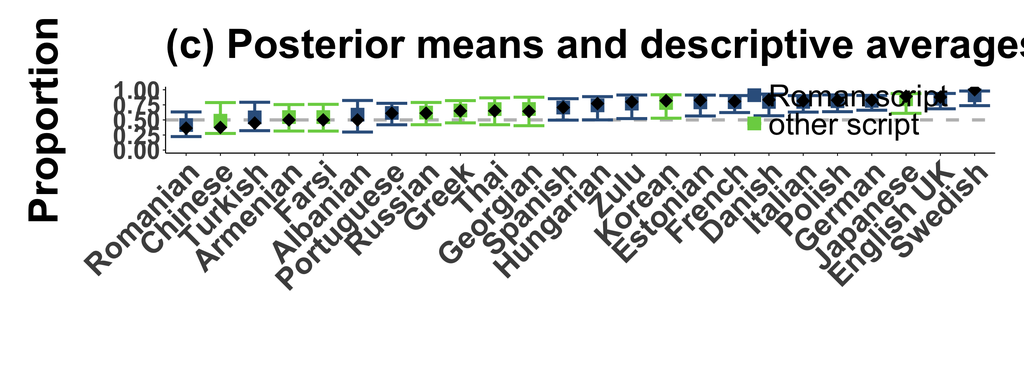

```r
# Aesthetics:

web_p <- preds %>%
  ggplot(aes(x = reorder(Language, Mean),
             y = Mean, col = Script))

# Geoms:

web_p <- web_p +
  geom_hline(yintercept = 0.5, linetype = 2, size = 1.5, col = 'grey') +
  geom_point(size = 6, shape = 15) +
  geom_errorbar(mapping = aes(ymin = Lower_CI, ymax = Upper_CI), size = 1.4) +
  geom_point(aes(y = ACC), col = 'black', shape = 18, size = 6)

# Extra stuff:

web_p <- web_p +
  labs(x = '', y = 'Proportion\n') +
  ggtitle('(c) Posterior means and descriptive averages of matching responses by language and script') +
  coord_cartesian(ylim = c(0, 1)) +
  scale_color_viridis_d(option = 'D', begin = 0.3, end = 0.8, direction = 1) +
  theme_timo +
  theme(axis.text.x = element_text(angle = 45, hjust = 1, face = 'bold',
                                   size = 30),
        axis.text.y = element_text(face = 'bold', size = 24),
        axis.title = element_text(face = 'bold', size = 40),
        axis.title.y = element_text(face = 'bold', size = 40),
        plot.title = element_text(face = 'bold', size = 40,
                                  margin = margin(t = 0, r = 0,
                                                  b = 20, l = 0)),
        legend.text = element_text(size = 30),
        legend.title = element_blank(),
        legend.position = c(0.95, 0.15),
        legend.justification = c('right', 'bottom'))

# Show:

web_p
```

```r
# Save:

ggsave(plot = web_p, filename = '../figures/Figure1c_Bayes_descriptive.pdf',
       width = 28, height = 12)
```

This completes this analysis.